# Poisson Analysis

Pablo Rodriguez

1/31/2020

## Pine Tree Fertility

The invasive species *Pinus nigra* of a native forest was studied in order to deciphre its reproductive biology.

The amount of pines produced in 1 year by pines trees bigger than 1.5metres. (The way this response variable was collected is how we know it responds to a poisson distribution: Pines collected in a continuum (in this case a time lapse of 1 year))

Other variables such as age (tree rings), height(metres) and basal area (cm$^2$) were also measured.

The Response Variable will be modeled according to a **“Link Log”** which models the Natural Logarithm of the mean. It is used is “counting” data that cannot take on negative values. (Poisson, Negative Binomial, Gamma distributions)

```r
##Different amount of trees, 13 years or older, were collected in different areas.
parcel = c(
  replicate(5, "T2P2"), replicate(5, "T1P5"), replicate(7, "T3P4"),
  replicate(8, "T5P8"), replicate(9, "T4P5"), replicate(8, "T6P9")
)
##Amount of pines counted (discrete variable)
N_pines = c(
  919,  1,  2,  745,  280,  133,  54,  115,  701,  6,
  358,  66,  331,  188,  554,  712,  539,  26,  546,  264,
  419,  26,  63,  249,  90,  230,  25,  806,  76,  3,  13,
  27,  663,  68,  21,  405,  551,  156,  593,  65,  100,  259
)

height = c(
  10.82,  4.7,  5.1,  10.18,  8.76,  7.7,  7.98,  7.1,  8.49,
  6.3,  8,  6.6,  9.59,  7.6,  9.3,  7.8,  11.15,  5.4,  7,
  4.8,  7.6,  4,  4.6,  6,  7,  6.8,  6.8,  7.98,  6.2,  4.3,
  8.49,  7,  10.49,  10.49,  4.55,  9.59,  7.74,  6.81,  7.5,
  4.93,  4.93,  4.93
)

age = c(
  20,  13,  14,  20,  19,  18,  18,  18,  19,  18,  19,
  19,  24,  22,  20,  20,  21,  16,  22,  18,  22,  13,
  16,  17,  15,  17,  18,  20,  15,  13,  19,  18,  22,
  21,  13,  21,  20,  16,  24,  16,  15,  15
)

basal_area = c(
  195564.9281,  10935.88403,  15174.67792,  89196.88402,
  68813.44548,  48305.12864,  41547.56284,  39760.78202,
  68349.27517,  20611.9894,  73921.67514,  NA,  127501.5378,
  NA,  103894.0399,  47143.52476,  92401.30853,  8824.733764,
  75555.30332,  20106.97838,  87092.01694,  6221.138852,
  14741.13813,  NA,  NA,  NA,  NA,  89809.49459,  18626.50284,
  3421.1944,  54739.1104,  27759.11269,  145220.1204,
  149986.7019,  6647.610055,  126794.6795,  69279.1866,
  21124.069,  109271.6611,  39996.40147,  23778.7148,
  12076.28216
)
pine = data.frame(parcel, N_pines, height, age, basal_area)
```

```r
#Libraries used
library(MASS)
library(GGally)
library(car)
library(ggplot2)
library(glmmTMB)
library(ggpubr)

#Functions used

my_custom_smooth = function(data, mapping, ...) {
  ggplot(data = data, mapping = mapping) +
    geom_point(color = I("gold2")) +
    geom_smooth(method = "lm", color = I("darkmagenta"), ...)
}

corColors = RColorBrewer::brewer.pal(n = 7, name = "RdYlGn")[2:6]

my_custom_cor_color = function(data, mapping, color = I("black"), sizeRange = c(1, 5), ...) {
  # get the x and y data to use the other code
  x <- GGally::eval_data_col(data, mapping$x)
  y <- GGally::eval_data_col(data, mapping$y)

  ct <- cor.test(x,y)

  r <- unname(ct$estimate)
  rt <- format(r, digits=2)[1]
  tt <- as.character(rt)

  # plot the cor value
  p <- ggally_text(
    label = tt,
    mapping = aes(),
    xP = 0.5, yP = 0.5,
    size = 6,
    color=color,
    ...
  ) +

    theme(
      panel.background = element_rect(fill="white",
                                      color = "black",
                                      linetype = "dashed"),
      panel.grid.minor = element_blank(),
      panel.grid.major = element_blank()
    )

  corColors <- RColorBrewer::brewer.pal(n = 7, name = "RdYlGn")[2:6]

  if (r <= -0.6) {
    corCol <- corColors[1]
  } else if (r <= -0.4) {
    corCol <- corColors[2]
  } else if (r < 0.5) {
    corCol <- corColors[3]
  } else if (r < 0.7) {
    corCol <- corColors[4]
  } else {
    corCol <- corColors[5]
  }
  p <- p + theme(
    panel.background = element_rect(fill= corCol)
  )
  ##Credit of formula due to Barret Schloerke
  p
}

##Pearson Residues vs Predicted Residues for checking Model Assumptions.

dispersionGraph = function(mdl)
{
  y = resid(mdl, type = "pearson")
  x = fitted(mdl)
  p = ggplot(pine, aes(x , y)) +
    geom_abline(slope = 0, intercept = 0, color = "red") +
    geom_point() +
    labs(x = "predicted", y = "Pearson residue")

  return(p)
}
```

Firstly I will do an exploratory analysis of the data:

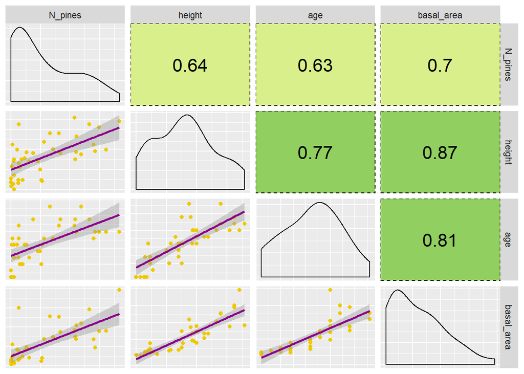

```r
pm = ggpairs(
  pine[,-1],
  upper = list(continuous = my_custom_cor_color),
  diag = list(continuous = "density"),
  lower = list(
    continuous = my_custom_smooth,
    combo = "dot"
  ),
  axisLabels = "none")
pm
```

Since there is clearly an association between explanatory variables it would be best to check the **Variance Inflation Factor**(VIF) of these variables

```r
vif(lm(N_pines ~ age + height + basal_area, data = pine)) # variance inflation factors
```

```
##        age     height basal_area
##   3.205525   4.641058   4.844550
```

There doesnt appear to be an apparent variance inflation due to a variable that explains the same information as another variable. This can be seen by the VIF values that are lower than 6.

The first model proposed therefore is:

$\eta$$_i$ = $\beta$$_0$ + $\beta$$_1$ * Age + $\beta$$_2$ * height + $\beta$$_3$ * Age*Height

Note the symbol eta $\eta$ which represents the Link Function that associates the response variable to the explanatory variables in a linear fashion.

```r
model1 = glm(N_pines ~ age * height, family = "poisson", data = pine)
##model residues
e = resid(model1)
pe = resid(model1, type = "pearson")
pre = fitted(model1)
residues = data.frame(e, pe, pre)
```

```r
summary(model1)
```

```
##
## Call:
## glm(formula = N_pines ~ age * height, family = "poisson", data = pine)
##
## Deviance Residuals:
##      Min        1Q    Median        3Q       Max
## -25.4333   -8.0617   -0.7332    5.9503   20.7669
##
## Coefficients:
##              Estimate Std. Error z value Pr(>|z|)
## (Intercept) -7.322300   0.405570  -18.05   <2e-16 ***
## age          0.593728   0.020761   28.60   <2e-16 ***
## height       1.388582   0.055559   24.99   <2e-16 ***
## age:height  -0.060997   0.002774  -21.99   <2e-16 ***
## ---
## Signif. codes:  0 '***' 0.001 '**' 0.01 '*' 0.05 '.' 0.1 ' ' 1
##
## (Dispersion parameter for poisson family taken to be 1)
##
##     Null deviance: 11182  on 41  degrees of freedom
## Residual deviance:  5298  on 38  degrees of freedom
## AIC: 5582.7
##
## Number of Fisher Scoring iterations: 5
```

All coefficients are statistically significant. but what happens when we look at the dispersion parameter?

```r
dispersionParametre = sum(resid(model1, type = "pearson")^2/model1$df.residual)

dispersionParametre
```

```
## [1] 131.4556
```

The dispersion parametre is greater than 1. This value would indicate a lack of dispersion. Since the value is at least 120X over there is clearly “over dispersion” which means that the variable’s variance is greater than what is expected for a poisson distribution. This will have severe consequences when estimating the standard error of the expanatory variable’s coefficients. The higher the “over dispersion” the lower the standard error the higher chance of committing type 1 error.

If we look at the residue patterns though…

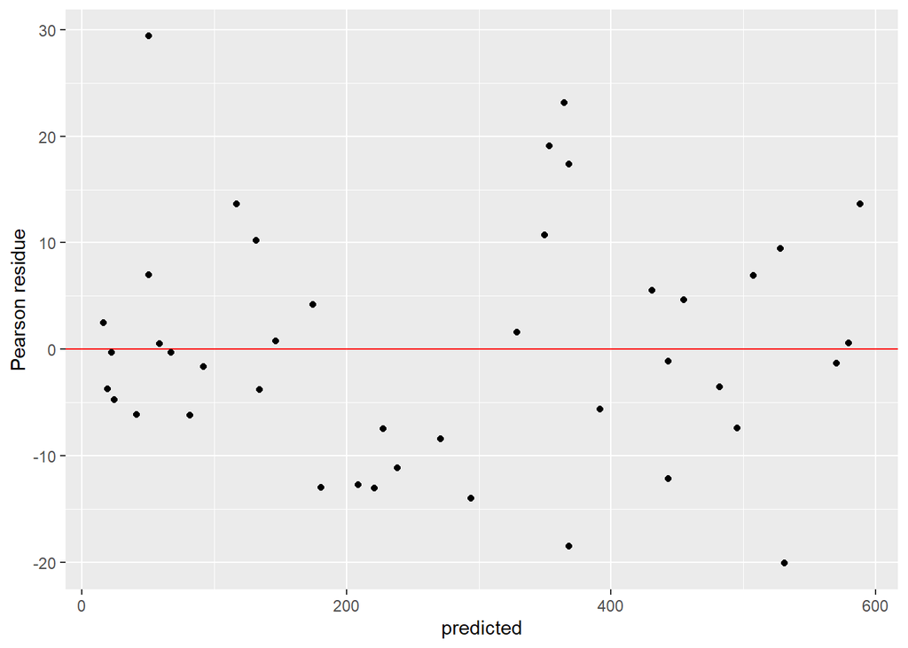

```r
dispersionGraph(model1)
```

And no apparent pattern can be seen. But it would be incorrect to continue analyzing this model with a poisson distribution.

Alain Zuur proposes that if you have over dispersion greater than 15 or 20 it is best to analyze a model through the Negative Binomial distribution.

```r
model2_bn = glm.nb(N_pines ~ age * height, data = pine)
em2 = resid(model2_bn)
epm2 = resid(model2_bn, type = "pearson")
ajust = fitted(model2_bn)
```

```r
summary(model2_bn)
```

```
##
## Call:
## glm.nb(formula = N_pines ~ age * height, data = pine, init.theta = 1.166373252,
##     link = log)
##
## Deviance Residuals:
##     Min       1Q   Median       3Q      Max
## -2.3661  -1.0465  -0.1663   0.3453   2.1928
##
## Coefficients:
##             Estimate Std. Error z value Pr(>|z|)
## (Intercept) -6.09605    3.73398  -1.633   0.1026
## age          0.55985    0.21077   2.656   0.0079 **
## height       1.09555    0.60082   1.823   0.0682 .
## age:height  -0.04972    0.03100  -1.604   0.1087
## ---
## Signif. codes:  0 '***' 0.001 '**' 0.01 '*' 0.05 '.' 0.1 ' ' 1
##
## (Dispersion parameter for Negative Binomial(1.1664) family taken to be 1)
##
##     Null deviance: 82.364  on 41  degrees of freedom
## Residual deviance: 47.619  on 38  degrees of freedom
## AIC: 534.83
##
## Number of Fisher Scoring iterations: 1
##
##
##               Theta:  1.166
##           Std. Err.:  0.236
##
##  2 x log-likelihood:  -524.828
```

```r
#Assumptions
n = nrow(pine)
param = length(coef(model2_bn)) + 1 #1 is added because "k" was estimated
```

```r
(dispersion = sum(resid(model2_bn, type = "pearson")^2/(n-param)))
```

```
## [1] 0.9412198
```

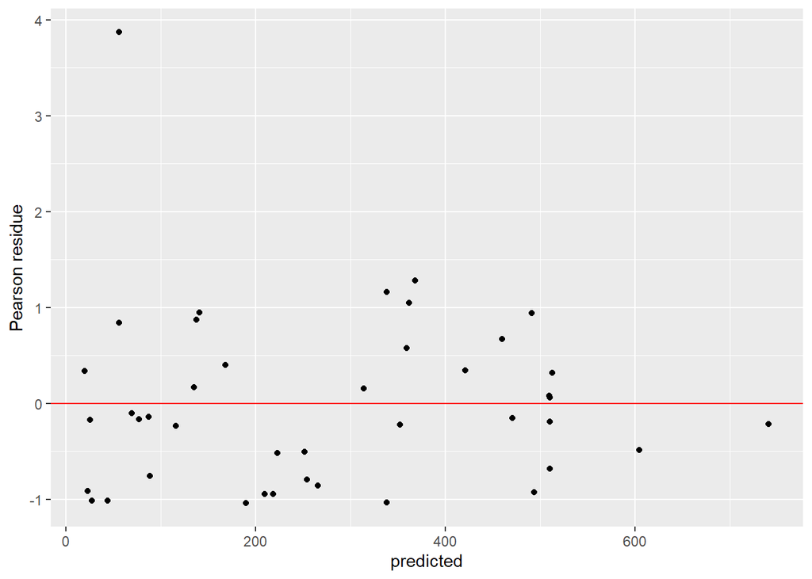

```r
dispersionGraph(model2_bn)
```

Here I will show that the data can be modelled with another probability distribution: Comway Maxwell Poisson. The results are practically the same, but since the over distribution for this set of data is greater than 20 I will analyze models modelled with the negative bionomial distribution.

```r
model3_cmp = glmmTMB(N_pines ~ age * height, data = pine, family = compois)
summary(model3_cmp)
```

```
##  Family: compois  ( log )
## Formula:          N_pines ~ age * height
## Data: pine
##
##      AIC      BIC   logLik deviance df.resid
##    529.6    538.3   -259.8    519.6       37
##
##
## Overdispersion parameter for compois family ():  291
##
## Conditional model:
##             Estimate Std. Error z value Pr(>|z|)
## (Intercept) -6.33086    3.51767  -1.800  0.07190 .
## age          0.55729    0.19032   2.928  0.00341 **
## height       1.20408    0.54326   2.216  0.02666 *
## age:height  -0.05341    0.02758  -1.936  0.05282 .
## ---
## Signif. codes:  0 '***' 0.001 '**' 0.01 '*' 0.05 '.' 0.1 ' ' 1
```

```r
AIC(model2_bn, model3_cmp)
```

```
##            df      AIC
## model2_bn   5 534.8284
## model3_cmp  5 529.6338
```

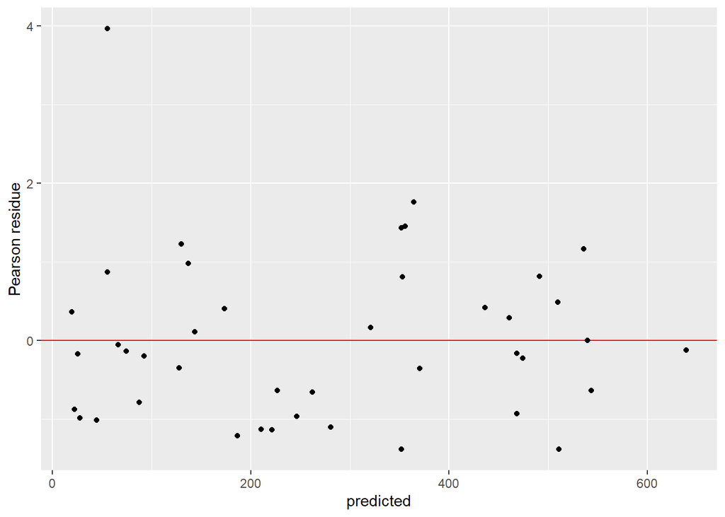

```r
fittedcmp = fitted(model3_cmp) #ajust in the response variable scale

dispersionGraph(model3_cmp)
```

```r
model4_bn = glm.nb(N_pines ~ age * height, data = pine, link = log)
model5_bn = glm.nb(N_pines ~ age + height, data = pine, link = log)
model6_bn = glm.nb(N_pines ~ age, data = pine, link = log)
model7_bn = glm.nb(N_pines ~ height, data = pine, link = log)
AIC(model4_bn,model5_bn,model6_bn,model7_bn)
```

```
##           df      AIC
## model4_bn  5 534.8284
## model5_bn  4 534.6671
## model6_bn  3 534.3024
## model7_bn  3 541.2781
```

Comparing the Aikaike values for the 4 models I choose to continue with models 4, 5 and 6 for they all present values similar up to the decimals.

```r
#Model Comparison

anova(model4_bn,model5_bn,model6_bn)
```

```
## Likelihood ratio tests of Negative Binomial Models
##
## Response: N_pines
##          Model    theta Resid. df    2 x log-lik.   Test    df LR stat.
## 1          age 1.087968        40       -528.3024
## 2 age + height 1.124637        39       -526.6671 1 vs 2     1 1.635378
## 3 age * height 1.166373        38       -524.8284 2 vs 3     1 1.838614
##     Pr(Chi)
## 1
## 2 0.2009608
## 3 0.1751134
```

```r
anova(model4_bn,model6_bn)
```

```
## Likelihood ratio tests of Negative Binomial Models
##
## Response: N_pines
##          Model    theta Resid. df    2 x log-lik.   Test    df LR stat.
## 1          age 1.087968        40       -528.3024
## 2 age * height 1.166373        38       -524.8284 1 vs 2     2 3.473992
##     Pr(Chi)
## 1
## 2 0.1760484
```

### Model 6:

### Linear Predictor Scale

#### $\eta$$_i$ = $\beta$$_0$ + $\beta$$_1$ * Age

### Link Function Scale

#### log$E$($\Upsilon$$_i$) = $\beta$$_0$ + $\beta$$_1$ * Age

### Response Variable Scale

#### $E$($\Upsilon$$_i$) = $e$$^\eta$ = $e$$^{\beta_{0}}$$^+$$^{\beta_{1}}$$^{*{Age}}$

The first step is to analyze if the model has more variables than necessary. I conduct a stepAIC, which removes a variable (much like the drop function) and analyzes and compares the AIC between models. Removing the variable "age from the analysis increases the AIC, therefore analysis will continue with model6_bn.

```r
#Model Modification and selection
stepAIC(model6_bn, test = "Chi")
```

```
## Start:  AIC=532.3
## N_pines ~ age
##
##        Df    AIC    LRT   Pr(Chi)
## <none>    532.30
## - age   1 553.46 23.153 1.496e-06 ***
## ---
## Signif. codes:  0 '***' 0.001 '**' 0.01 '*' 0.05 '.' 0.1 ' ' 1
```

```
##
## Call:  glm.nb(formula = N_pines ~ age, data = pine, link = log, init.theta = 1.087968392)
##
## Coefficients:
## (Intercept)          age
##     -0.8207       0.3358
##
## Degrees of Freedom: 41 Total (i.e. Null);  40 Residual
## Null Deviance:       76.97
## Residual Deviance: 47.9  AIC: 534.3
```

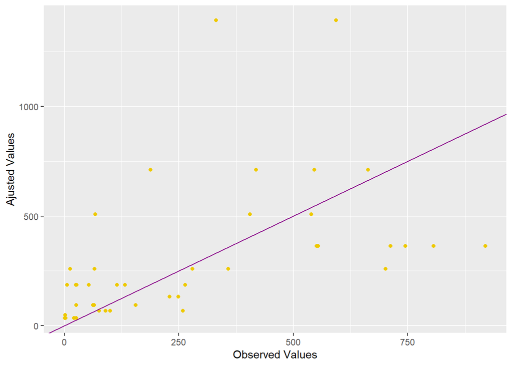

```r
ObsVSpred = ggplot(data = pine, aes(x = N_pines, y = model6_bn$fitted.values)) +
  geom_point(colour = "gold2") +
  geom_abline(slope = 1, intercept = 0, colour = "darkmagenta", )+
  labs(y = "Ajusted Values", x = "Observed Values")
ObsVSpred
```

```r
##Explained Deviance
((model6_bn$null.deviance-model6_bn$deviance)/model6_bn$null.deviance)*100
```

```
## [1] 37.77179
```

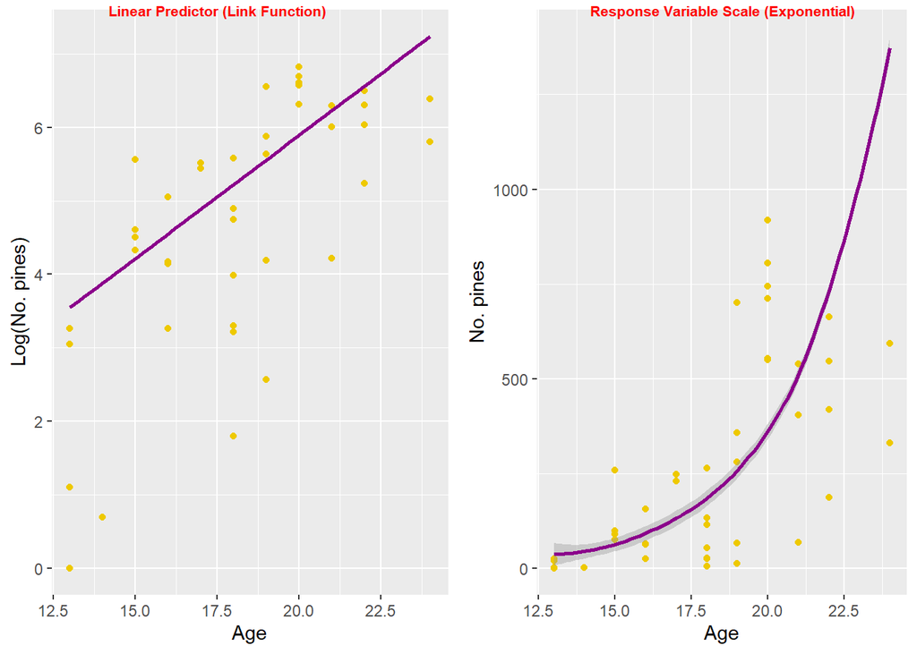

```r
##Linear Predictor
new_age = data.frame(age = min(pine$age) : max(pine$age))
eta = predict(model6_bn, new_age)

linear = ggplot() +
  geom_point(data = pine, aes(pine$age, log(pine$N_pines)), colour = "gold2") +
  labs(x = "Age", y = "Log(No. pines)") +
  geom_smooth(data = new_age, aes(x = new_age$age, y = eta), colour = "darkmagenta")

count = ggplot() +
  geom_point(data = pine, aes(x = age, y = N_pines), colour = "gold2") +
  labs( x = "Age", y = "No. pines") +
  geom_smooth(data = new_age, aes(x = new_age$age, y = exp(eta)), colour = "darkmagenta")

figure = ggarrange(linear, count,
                   ncol = 2, nrow = 1,
                   labels = c("Linear Predictor (Link Function)",
                   "Response Variable Scale (Exponential)"),
                   font.label = list(size = 8, color = "red"))
figure
```